# Einfluss CO2-Preis auf den Aktienkurs von EVU

Joël Felder, Stefan Berchtold

Dokument erstellt am 03.04.2020

## Ausgangslage

Benutzte Libraries für diese Arbeit

```r
library (xts)
library (fBasics)
library (ggfortify)
library (ggplot2)
library (timeSeries)
library (tseries)
library (zoo)
library (plotly)
library (vars)
library (fpp2)
```

Einlesen der Daten

```r
co2_evu <- read.csv("timeseries-1.csv", header = TRUE, sep = ";")
```

Umwandlug des Datensatzes in Zeitreihe

```r
daten <-xts(co2_evu[,-1], order.by=as.Date(co2_evu$X, "%d.%m.%y"))
attr(daten, 'frequency') <- 7
periodicity(daten)
```

```
## Daily periodicity from 2012-11-02 to 2019-11-21
```

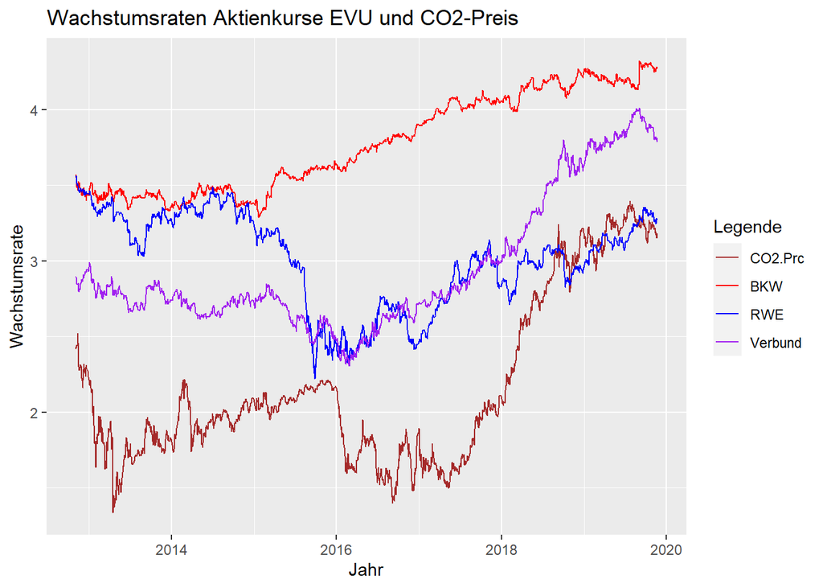

```r
autoplot(log(daten[,-2:-3]), facets = FALSE)+
  ggtitle("Wachstumsraten Aktienkurse EVU und CO2-Preis") + xlab("Jahr") + ylab("Wachstumsrate")+
  labs(color="Legende") +
  scale_colour_manual(breaks = c("CO2.Prc", "BKW", "RWE", "Verbund"),
                      values = c("brown", "red", "blue", "purple"))
```

## Datenaufbereitung

Dekomposition der Zeitreihen

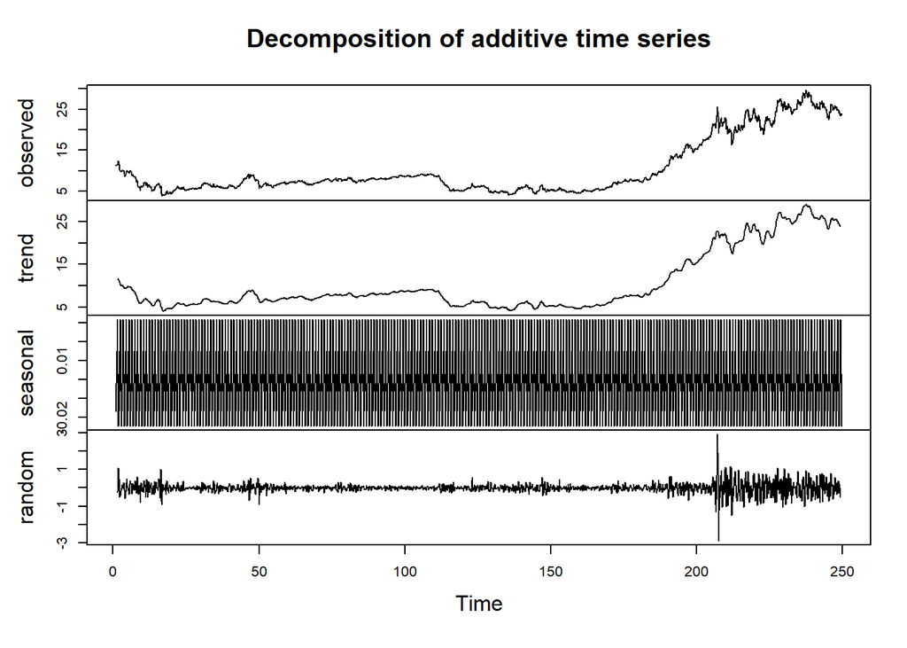

```r
## CO2 Preis
plot(decompose(as.ts(daten$CO2.Prc)))
```

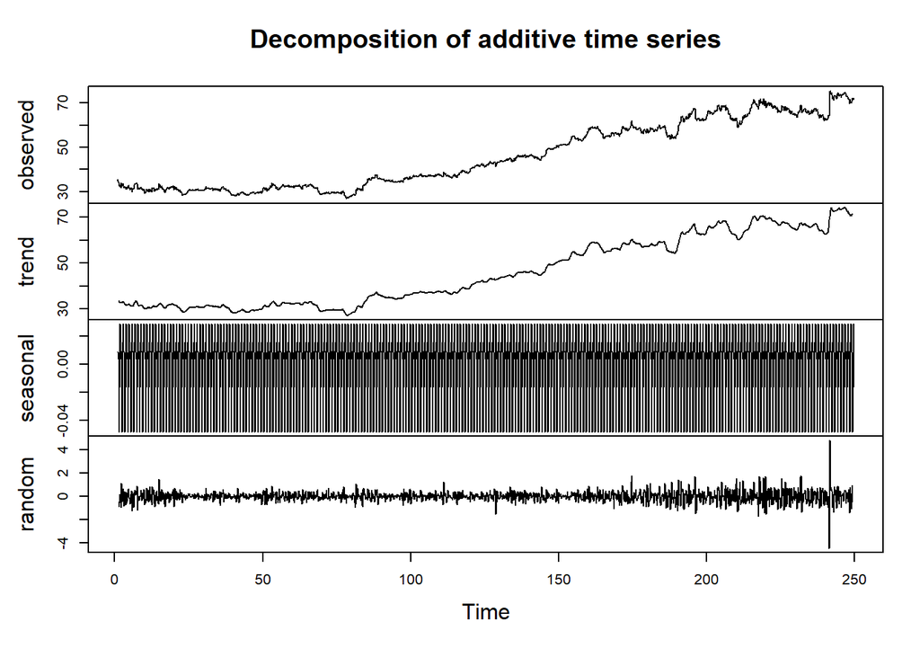

```r
## Aktienkurs BKW AG
plot(decompose(as.ts(daten$BKW)))
```

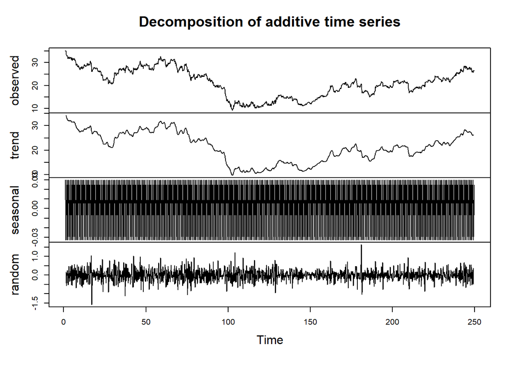

```r
## Atienkurs RWE AG
plot(decompose(as.ts(daten$RWE)))
```

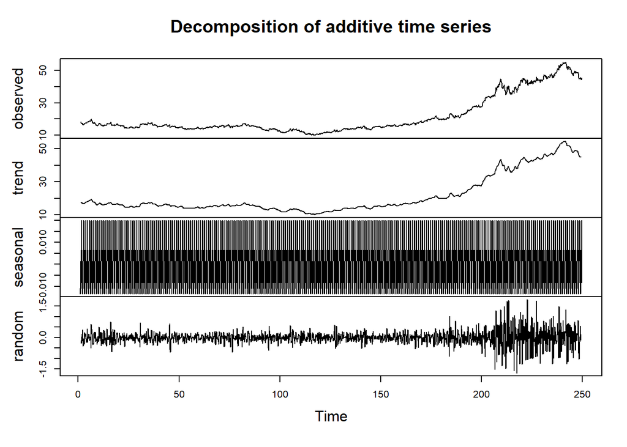

```r
## Aktienkurs Verbund AG
plot(decompose(as.ts(daten$Verbund)))
```

Testen auf Stationarität

```r
adf.test(daten$CO2.Prc)
```

```
##
##  Augmented Dickey-Fuller Test
##
## data:  daten$CO2.Prc
## Dickey-Fuller = -1.7003, Lag order = 12, p-value = 0.7052
## alternative hypothesis: stationary
```

```r
adf.test(daten$BKW)
```

```
##
##  Augmented Dickey-Fuller Test
##
## data:  daten$BKW
## Dickey-Fuller = -3.2989, Lag order = 12, p-value = 0.07085
## alternative hypothesis: stationary
```

```r
adf.test(daten$RWE)
```

```
##
##  Augmented Dickey-Fuller Test
##
## data:  daten$RWE
## Dickey-Fuller = -1.2905, Lag order = 12, p-value = 0.8787
## alternative hypothesis: stationary
```

```r
adf.test(daten$Verbund)
```

```
##
##  Augmented Dickey-Fuller Test
##
## data:  daten$Verbund
## Dickey-Fuller = -1.101, Lag order = 12, p-value = 0.9224
## alternative hypothesis: stationary
```

Keine der untersuchten Zeitreihen ist stationär. Um Stationarität zu erreichen, werden die Zeitreihen differenziert und logarithmiert. Dies führt zu stetigen Renditen.

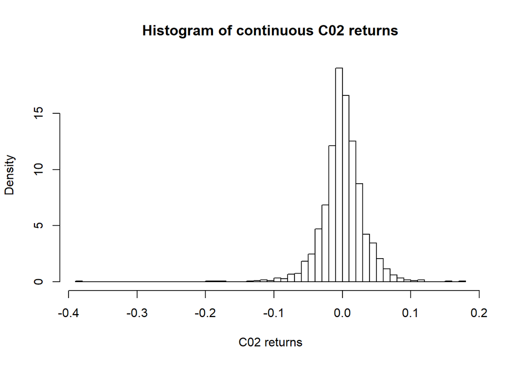

```r
dco2 <- diff(log(daten$CO2.Prc))[-1]
dbkw <- diff(log(daten$BKW))[-1]
drwe <- diff(log(daten$RWE))[-1]
dverbund <- diff(log(daten$Verbund))[-1]

hist(dco2, breaks = 50, main = "Histogram of continuous C02 returns", xlab="C02 returns",freq = FALSE)
```

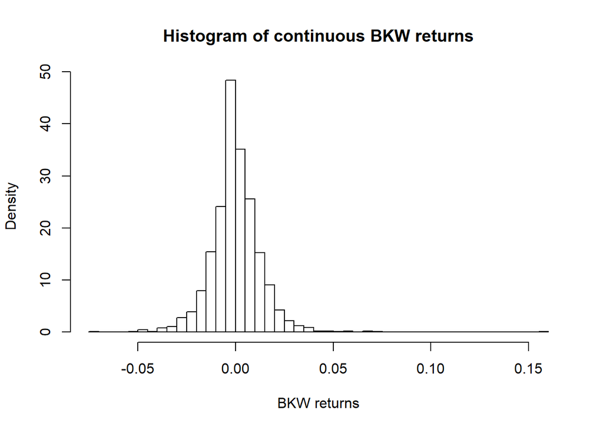

```r
hist(dbkw, breaks = 50, main = "Histogram of continuous BKW returns", xlab="BKW returns",freq = FALSE)
```

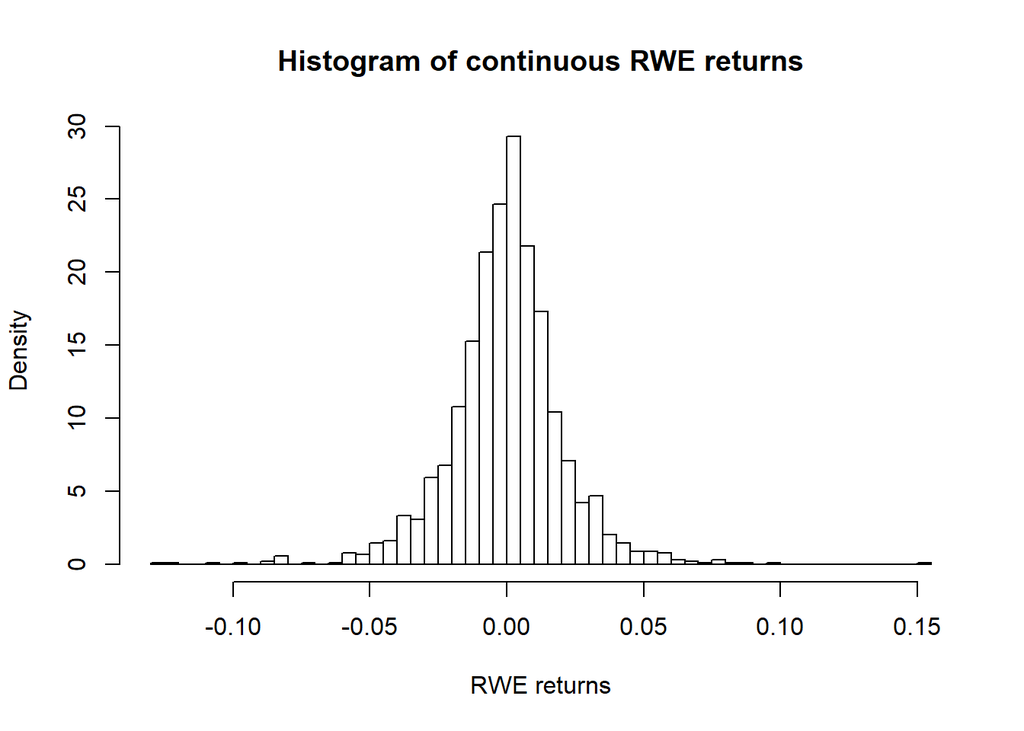

```r
hist(drwe, breaks = 50, main = "Histogram of continuous RWE returns", xlab="RWE returns", freq = FALSE)
```

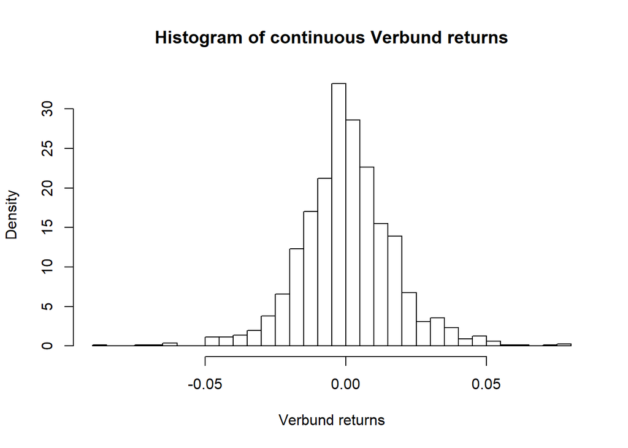

```r
hist(dverbund, breaks = 50, main = "Histogram of continuous Verbund returns", xlab="Verbund returns", freq = FALSE)
```

Die Histogramme zeigen, dass die stetigen Renditen annährend normalverteilt sind.

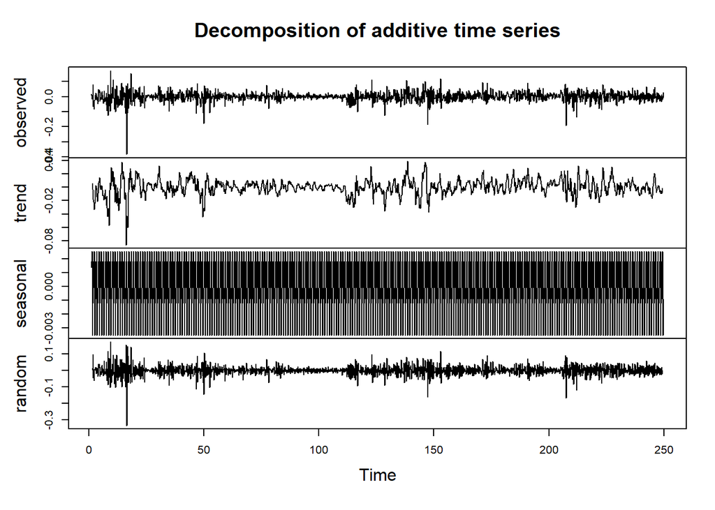

```r
## CO2 Renditen
plot(decompose((diff(log(as.ts(daten$CO2.Prc))))))
```

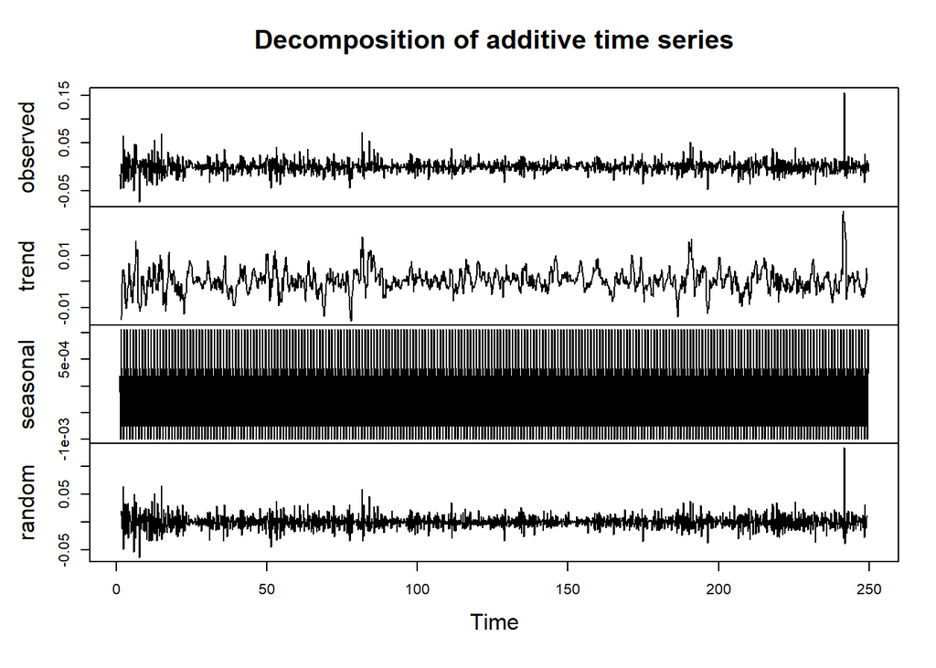

```r
## Renditen BKW AG
plot(decompose((diff(log(as.ts(daten$BKW))))))
```

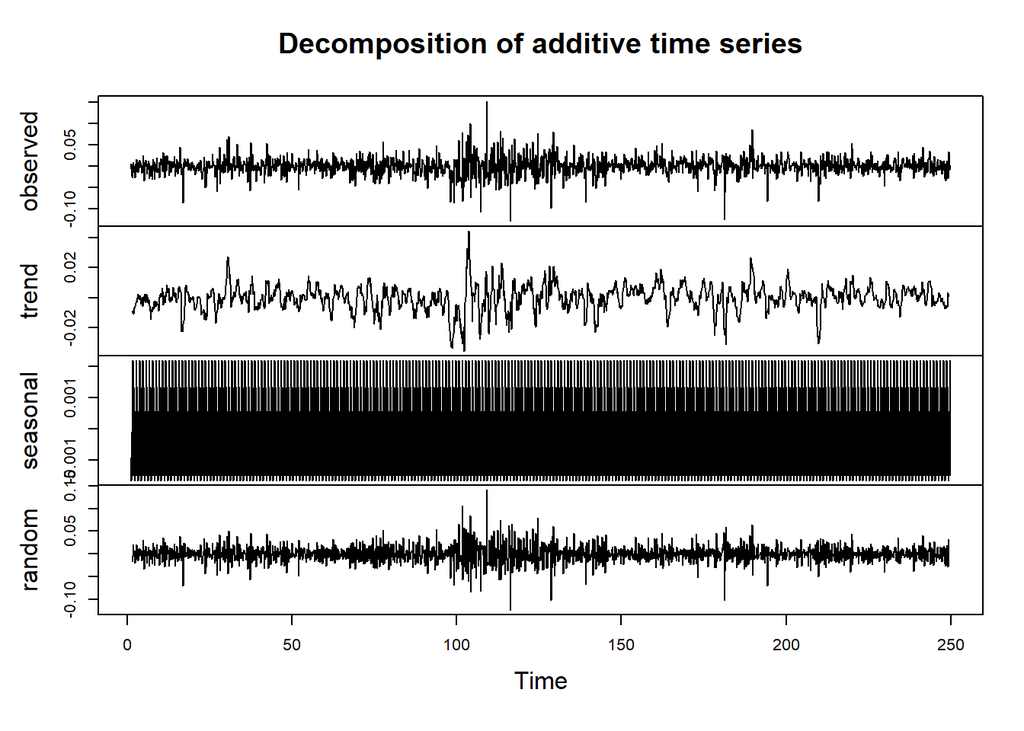

```r
## Renditen RWE AG
plot(decompose(diff(log((as.ts(daten$RWE))))))
```

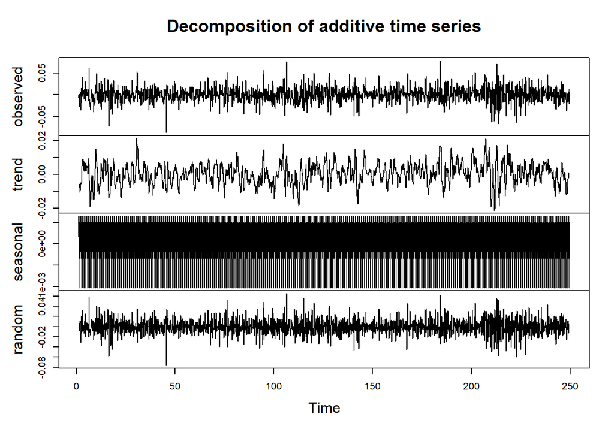

```r
## Renditen Verbund AG
plot(decompose(diff(log(as.ts(daten$Verbund)))))
```

Ein erneuter Blick auf die Dekomposition der Zeitreihen zeigt, dass die Saisonalität klar reduziert wurde sowie kein klarer Trend erkennbar ist.

```r
adf.test(dco2)
```

```
##
##  Augmented Dickey-Fuller Test
##
## data:  dco2
## Dickey-Fuller = -12.261, Lag order = 12, p-value = 0.01
## alternative hypothesis: stationary
```

```r
adf.test(dbkw)
```

```
##
##  Augmented Dickey-Fuller Test
##
## data:  dbkw
## Dickey-Fuller = -12.145, Lag order = 12, p-value = 0.01
## alternative hypothesis: stationary
```

```r
adf.test(drwe)
```

```
##
##  Augmented Dickey-Fuller Test
##
## data:  drwe
## Dickey-Fuller = -12.386, Lag order = 12, p-value = 0.01
## alternative hypothesis: stationary
```

```r
adf.test(dverbund)
```

```
##
##  Augmented Dickey-Fuller Test
##
## data:  dverbund
## Dickey-Fuller = -11.997, Lag order = 12, p-value = 0.01
## alternative hypothesis: stationary
```

Der p-Wert der Dickey-Fuller Tests ist bei allen Zeitreihen statistisch signifikant. Anhand der nun stationären Zeitreihen werden als nächstes mehrere vektorautoregressive Modelle geschätzt.

## Vektorautoregressives Modell

```r
var_bkw <- VAR(cbind(dbkw, dco2), type = "const", ic = "AIC")
summary(VAR(cbind(dbkw, dco2), type = "const", ic = "AIC"))
```

```
##
## VAR Estimation Results:
## =========================
## Endogenous variables: BKW, CO2.Prc
## Deterministic variables: const
## Sample size: 1741
## Log Likelihood: 8613.815
## Roots of the characteristic polynomial:
## 0.1094 0.01908
## Call:
## VAR(y = cbind(dbkw, dco2), type = "const", ic = "AIC")
##
##
## Estimation results for equation BKW:
## ====================================
## BKW = BKW.l1 + CO2.Prc.l1 + const
##
##              Estimate Std. Error t value Pr(>|t|)
## BKW.l1     -0.1069021  0.0238414  -4.484 7.81e-06 ***
## CO2.Prc.l1  0.0031575  0.0097650   0.323    0.746
## const       0.0004559  0.0003124   1.460    0.145
## ---
## Signif. codes:  0 '***' 0.001 '**' 0.01 '*' 0.05 '.' 0.1 ' ' 1
##
##
## Residual standard error: 0.01303 on 1738 degrees of freedom
## Multiple R-Squared: 0.01151, Adjusted R-squared: 0.01037
## F-statistic: 10.12 on 2 and 1738 DF,  p-value: 4.273e-05
##
##
## Estimation results for equation CO2.Prc:
## ========================================
## CO2.Prc = BKW.l1 + CO2.Prc.l1 + const
##
##             Estimate Std. Error t value Pr(>|t|)
## BKW.l1     0.1011487  0.0585060   1.729    0.084 .
## CO2.Prc.l1 0.0165462  0.0239630   0.690    0.490
## const      0.0003768  0.0007666   0.492    0.623
## ---
## Signif. codes:  0 '***' 0.001 '**' 0.01 '*' 0.05 '.' 0.1 ' ' 1
##
##
## Residual standard error: 0.03197 on 1738 degrees of freedom
## Multiple R-Squared: 0.001978,    Adjusted R-squared: 0.0008292
## F-statistic: 1.722 on 2 and 1738 DF,  p-value: 0.179
##
##
##
## Covariance matrix of residuals:
##                BKW    CO2.Prc
## BKW      1.697e-04 -1.890e-06
## CO2.Prc -1.890e-06  1.022e-03
##
## Correlation matrix of residuals:
##               BKW   CO2.Prc
## BKW      1.000000 -0.004538
## CO2.Prc -0.004538  1.000000
```

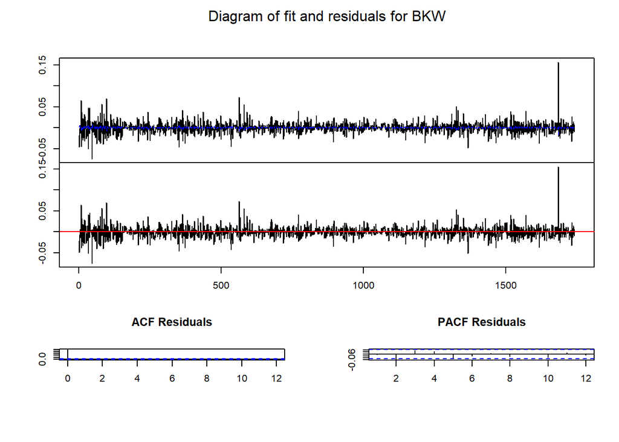

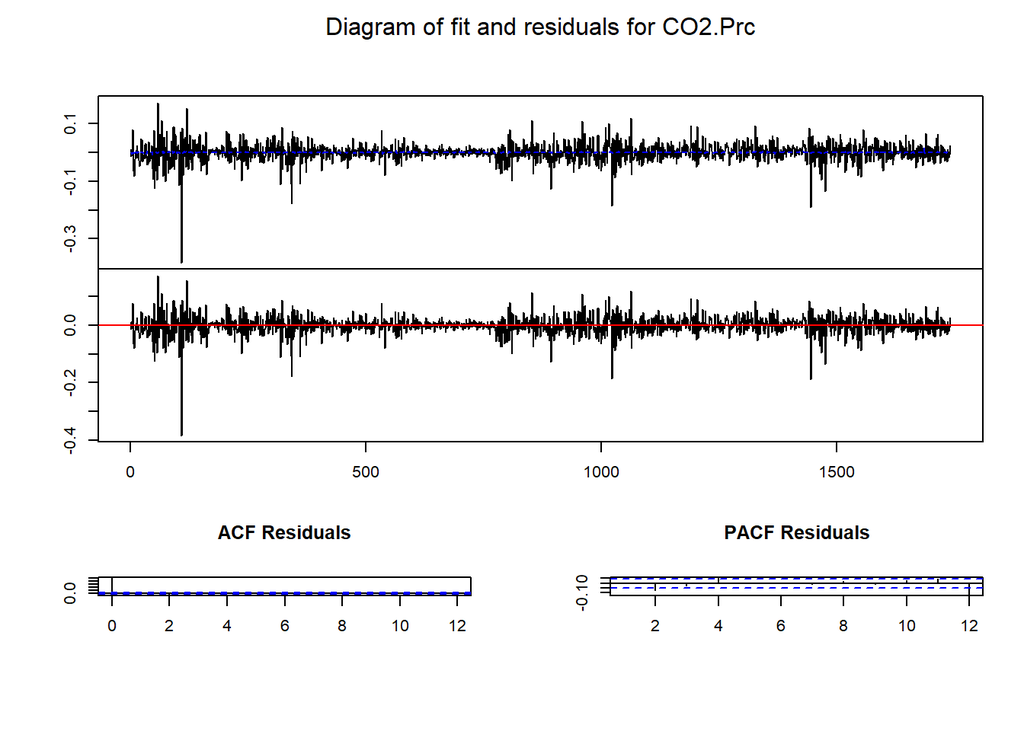

```r
plot(var_bkw)
```

```r
var_rwe <- VAR(cbind(dco2, drwe), type = "const", ic = "AIC")
summary(VAR(cbind(dco2, drwe), type = "const", ic = "AIC"))
```

```
##
## VAR Estimation Results:
## =========================
## Endogenous variables: CO2.Prc, RWE
## Deterministic variables: const
## Sample size: 1741
## Log Likelihood: 7775.789
## Roots of the characteristic polynomial:
## 0.02641 0.02641
## Call:
## VAR(y = cbind(dco2, drwe), type = "const", ic = "AIC")
##
##
## Estimation results for equation CO2.Prc:
## ========================================
## CO2.Prc = CO2.Prc.l1 + RWE.l1 + const
##
##              Estimate Std. Error t value Pr(>|t|)
## CO2.Prc.l1  0.0167623  0.0240153   0.698    0.485
## RWE.l1     -0.0169925  0.0364011  -0.467    0.641
## const       0.0004153  0.0007669   0.542    0.588
##
##
## Residual standard error: 0.03199 on 1738 degrees of freedom
## Multiple R-Squared: 0.0003866,   Adjusted R-squared: -0.0007637
## F-statistic: 0.3361 on 2 and 1738 DF,  p-value: 0.7146
##
##
## Estimation results for equation RWE:
## ====================================
## RWE = CO2.Prc.l1 + RWE.l1 + const
##
##              Estimate Std. Error t value Pr(>|t|)
## CO2.Prc.l1  0.0248553  0.0158337   1.570    0.117
## RWE.l1      0.0164130  0.0239998   0.684    0.494
## const      -0.0001696  0.0005056  -0.335    0.737
##
##
## Residual standard error: 0.02109 on 1738 degrees of freedom
## Multiple R-Squared: 0.001755,    Adjusted R-squared: 0.000606
## F-statistic: 1.528 on 2 and 1738 DF,  p-value: 0.2174
##
##
##
## Covariance matrix of residuals:
##           CO2.Prc       RWE
## CO2.Prc 1.024e-03 3.578e-05
## RWE     3.578e-05 4.449e-04
##
## Correlation matrix of residuals:
##         CO2.Prc     RWE
## CO2.Prc 1.00000 0.05302
## RWE     0.05302 1.00000
```

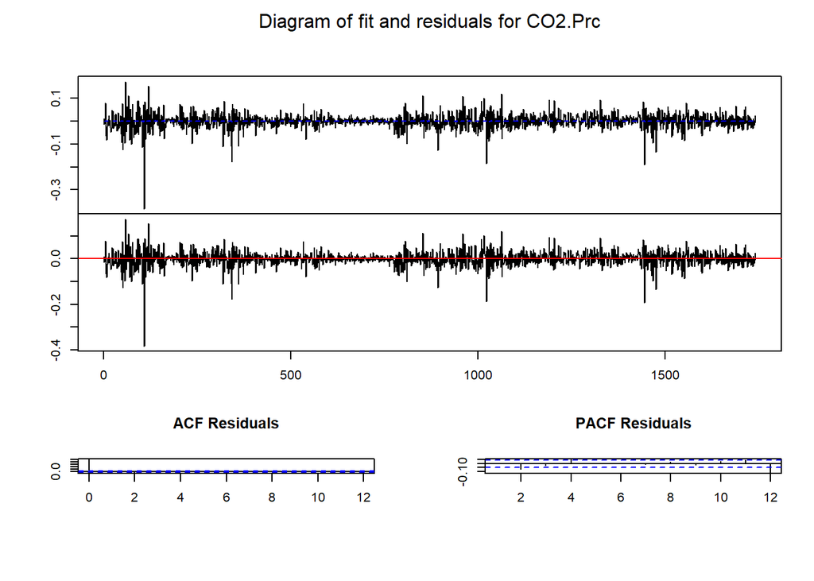

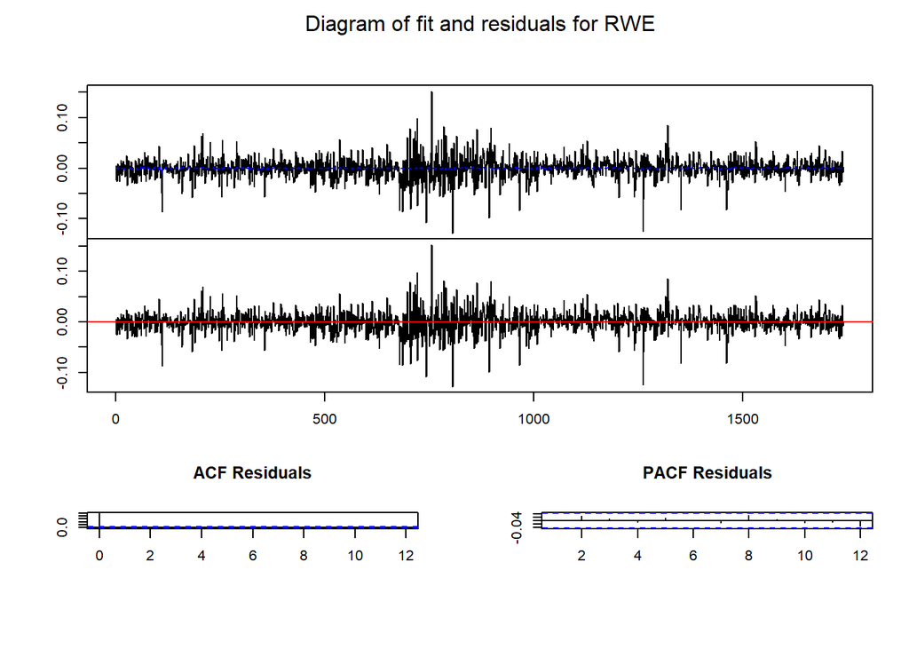

```r
plot(var_rwe)
```

```r
var_verbund <- VAR(cbind(dco2, dverbund), type = "const", ic = "AIC")
summary(VAR(cbind(dco2, dverbund), type = "const", ic = "AIC"))
```

```
##
## VAR Estimation Results:
## =========================
## Endogenous variables: CO2.Prc, Verbund
## Deterministic variables: const
## Sample size: 1741
## Log Likelihood: 8222.236
## Roots of the characteristic polynomial:
## 0.04183 0.01479
## Call:
## VAR(y = cbind(dco2, dverbund), type = "const", ic = "AIC")
##
##
## Estimation results for equation CO2.Prc:
## ========================================
## CO2.Prc = CO2.Prc.l1 + Verbund.l1 + const
##
##             Estimate Std. Error t value Pr(>|t|)
## CO2.Prc.l1 0.0142723  0.0244338   0.584    0.559
## Verbund.l1 0.0189729  0.0469276   0.404    0.686
## const      0.0004094  0.0007672   0.534    0.594
##
##
## Residual standard error: 0.03199 on 1738 degrees of freedom
## Multiple R-Squared: 0.0003553,   Adjusted R-squared: -0.000795
## F-statistic: 0.3089 on 2 and 1738 DF,  p-value: 0.7343
##
##
## Estimation results for equation Verbund:
## ========================================
## Verbund = CO2.Prc.l1 + Verbund.l1 + const
##
##             Estimate Std. Error t value Pr(>|t|)
## CO2.Prc.l1 0.0422125  0.0126808   3.329  0.00089 ***
## Verbund.l1 0.0127724  0.0243547   0.524  0.60004
## const      0.0005053  0.0003981   1.269  0.20454
## ---
## Signif. codes:  0 '***' 0.001 '**' 0.01 '*' 0.05 '.' 0.1 ' ' 1
##
##
## Residual standard error: 0.0166 on 1738 degrees of freedom
## Multiple R-Squared: 0.007131,    Adjusted R-squared: 0.005989
## F-statistic: 6.241 on 2 and 1738 DF,  p-value: 0.001991
##
##
##
## Covariance matrix of residuals:
##           CO2.Prc   Verbund
## CO2.Prc 0.0010236 0.0001014
## Verbund 0.0001014 0.0002757
##
## Correlation matrix of residuals:
##         CO2.Prc Verbund
## CO2.Prc  1.0000  0.1908
## Verbund  0.1908  1.0000
```

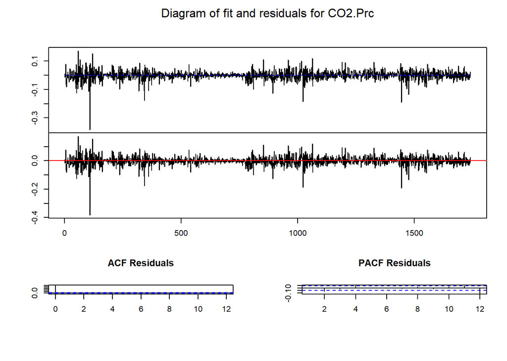

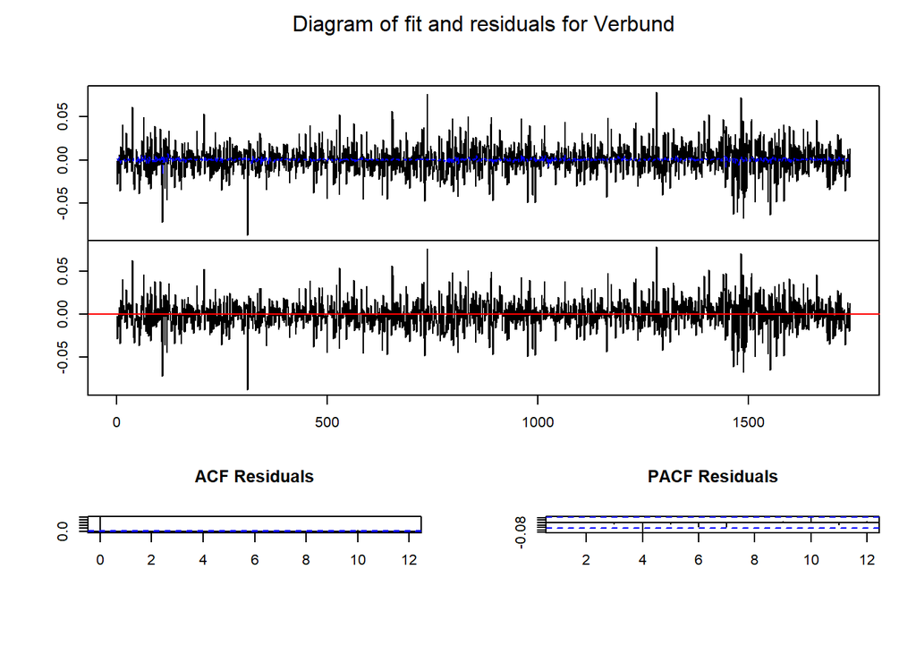

```r
plot(var_verbund)
```

Man sieht, dass die BKW AG Returns mit Lag 1 signifikant unterschiedlich von 0 ist und somit Einfluss auf den Return heute hat. Die CO2 Returns scheinen keinen Einfluss zu haben. Beim vektorautoregressiven Modell für die RWE AG ist keine Variable statistisch signifikant unterschiedlich von 0. Im Modell der Verbund AG scheint der CO2 Return mit Lag 1 statistisch signifikant unterschiedlich von 0 zu sein. Die Residuen aller Modelle folgen einer Gaussian White Noise.

##Granger Kausalitätstest

```r
causality(var_bkw, cause = "CO2.Prc")
```

```
## $Granger
##
##  Granger causality H0: CO2.Prc do not Granger-cause BKW
##
## data:  VAR object var_bkw
## F-Test = 0.10455, df1 = 1, df2 = 3476, p-value = 0.7465
##
##
## $Instant
##
##  H0: No instantaneous causality between: CO2.Prc and BKW
##
## data:  VAR object var_bkw
## Chi-squared = 0.035845, df = 1, p-value = 0.8498
```

```r
causality(var_bkw, cause = "BKW")
```

```
## $Granger
##
##  Granger causality H0: BKW do not Granger-cause CO2.Prc
##
## data:  VAR object var_bkw
## F-Test = 2.989, df1 = 1, df2 = 3476, p-value = 0.08392
##
##
## $Instant
##
##  H0: No instantaneous causality between: BKW and CO2.Prc
##
## data:  VAR object var_bkw
## Chi-squared = 0.035845, df = 1, p-value = 0.8498
```

```r
causality(var_rwe, cause = "CO2.Prc")
```

```
## $Granger
##
##  Granger causality H0: CO2.Prc do not Granger-cause RWE
##
## data:  VAR object var_rwe
## F-Test = 2.4642, df1 = 1, df2 = 3476, p-value = 0.1166
##
##
## $Instant
##
##  H0: No instantaneous causality between: CO2.Prc and RWE
##
## data:  VAR object var_rwe
## Chi-squared = 4.8796, df = 1, p-value = 0.02718
```

```r
causality(var_rwe, cause = "RWE")
```

```
## $Granger
##
##  Granger causality H0: RWE do not Granger-cause CO2.Prc
##
## data:  VAR object var_rwe
## F-Test = 0.21792, df1 = 1, df2 = 3476, p-value = 0.6407
##
##
## $Instant
##
##  H0: No instantaneous causality between: RWE and CO2.Prc
##
## data:  VAR object var_rwe
## Chi-squared = 4.8796, df = 1, p-value = 0.02718
```

```r
causality(var_verbund, cause = "CO2.Prc")
```

```
## $Granger
##
##  Granger causality H0: CO2.Prc do not Granger-cause Verbund
##
## data:  VAR object var_verbund
## F-Test = 11.081, df1 = 1, df2 = 3476, p-value = 0.0008811
##
##
## $Instant
##
##  H0: No instantaneous causality between: CO2.Prc and Verbund
##
## data:  VAR object var_verbund
## Chi-squared = 61.156, df = 1, p-value = 5.218e-15
```

```r
causality(var_verbund, cause = "Verbund")
```

```
## $Granger
##
##  Granger causality H0: Verbund do not Granger-cause CO2.Prc
##
## data:  VAR object var_verbund
## F-Test = 0.16346, df1 = 1, df2 = 3476, p-value = 0.686
##
##
## $Instant
##
##  H0: No instantaneous causality between: Verbund and CO2.Prc
##
## data:  VAR object var_verbund
## Chi-squared = 61.156, df = 1, p-value = 5.218e-15
```

Der Granger Kausalitäts Test zeigt dass, im 95% Konfidenzintervall, einzig Änderungen im CO2 Return signifikante Änderungen der Verbund AG Returns bewirkt. Alle anderen Variablen sind nicht Granger-kausal.

## Impulse Response Funktion

Als nächste wird untersucht, inwiefern Schocks im CO2 Preis die Aktienkurse der untersuchten Firmen beeinflusst.

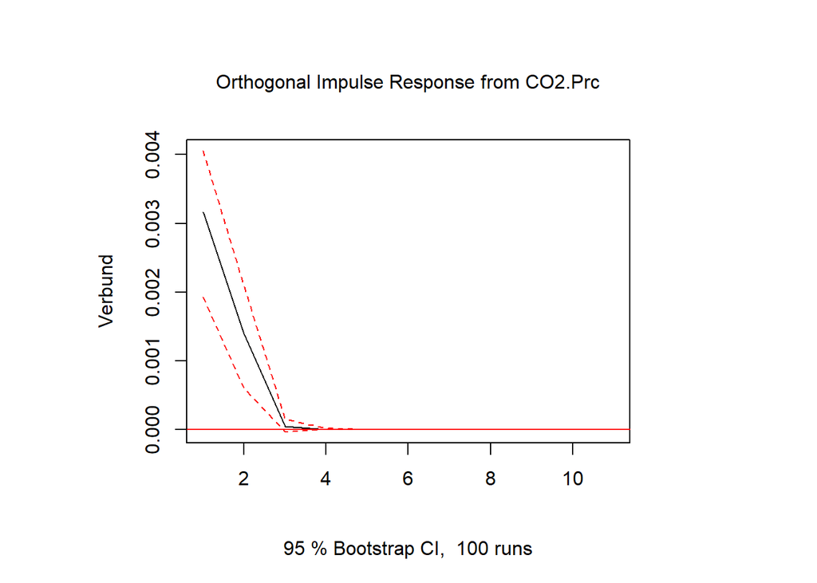

```r
plot(irf(var_verbund, impulse = "CO2.Prc", response = "Verbund"))
```

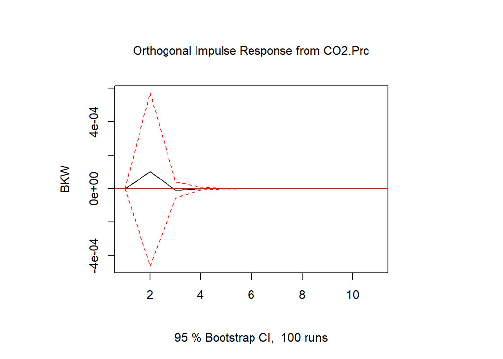

```r
plot(irf(var_bkw,impulse = "CO2.Prc", response = "BKW"))
```

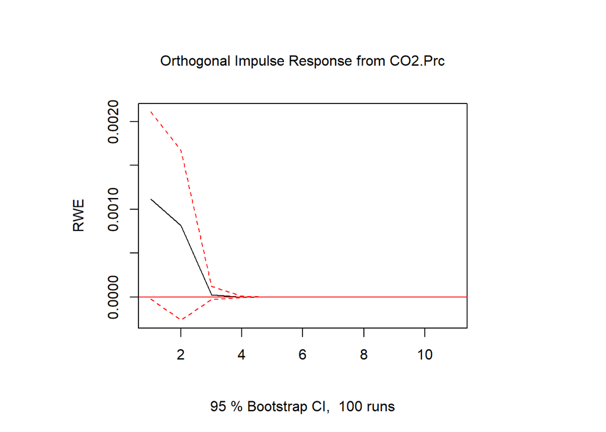

```r
plot(irf(var_rwe, impulse = "CO2.Prc", response = "RWE"))
```

Ein Schock des CO2 Preises bewirkt eine vernachlässigbare Änderung der Returns der BKW AG. Bei der RWE AG bewirkt der Schock eine kleine Veränderung der Returns über mehrer Perionden. Den grössten Effekt, auch über mehrer Perioden, hat der Schock auf die Veränderung der Returns der Verbund AG.

## Einzelanalyse der Verbund AG

Der CO2-Preis hat auf die Verbund AG den signifikantesten Einfluss. In einem letzten Schritt wurde versucht, das Modell der Verbund AG zu verbessern, da das R-squared nur 0.007131 beträgt. Dies bedeutet, dass nur 0.7% der Variabilität der Zeitreihe mit dem Modell erklärt werden kann. Dabei wurde als erstes das Volumen der gehandelten CO2-Zertifikate betrachtet. Mehr Volumen sollte zu genaueren Pricing führen und allgemein mehr Informationen im Preis enthalten. Dies könnte das Modell verbessern.

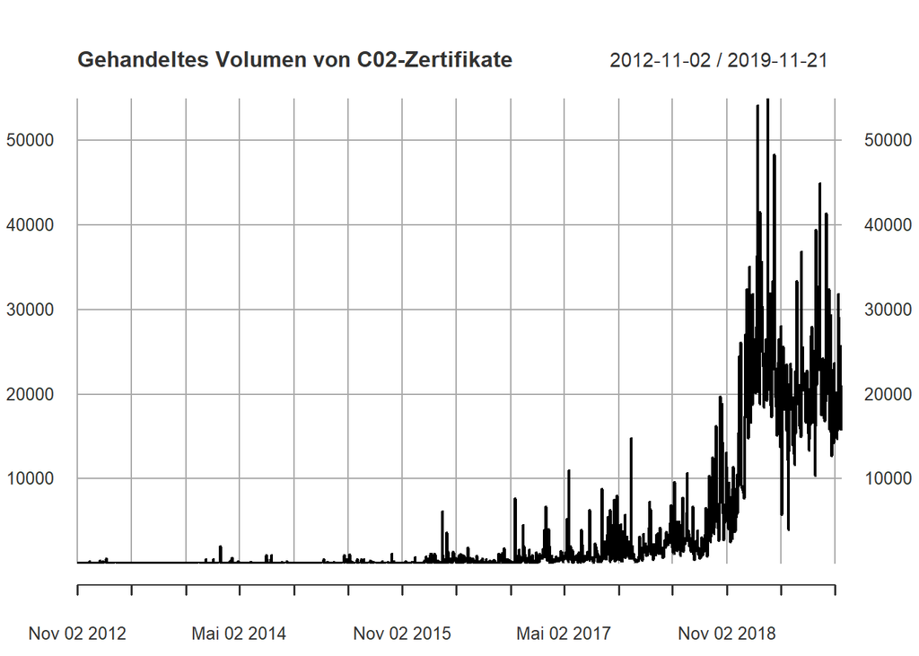

```r
plot(daten$CO2.Vol, main = "Gehandeltes Volumen von C02-Zertifikate")
```

Man sieht, dass das gehandelte Volumen der CO2 Zertifikate etwa ab 2017 rapide ansteigt. Deswegen wird die Zeitreihe ab 2017 etwas genauer untersucht.

```r
daten1<-daten[c("2017","2018","2019")]


dco21 <- diff(log(daten1$CO2.Prc))[-1]
dverbund1 <- diff(log(daten1$Verbund))[-1]

var_verbund1 <- VAR(cbind(dco21, dverbund1), type = "const", ic = "AIC")
summary(VAR(cbind(dco21, dverbund1), type = "const", ic = "AIC"))
```

```
##
## VAR Estimation Results:
## =========================
## Endogenous variables: CO2.Prc, Verbund
## Deterministic variables: const
## Sample size: 717
## Log Likelihood: 3453.182
## Roots of the characteristic polynomial:
## 0.04914 0.04914
## Call:
## VAR(y = cbind(dco21, dverbund1), type = "const", ic = "AIC")
##
##
## Estimation results for equation CO2.Prc:
## ========================================
## CO2.Prc = CO2.Prc.l1 + Verbund.l1 + const
##
##             Estimate Std. Error t value Pr(>|t|)
## CO2.Prc.l1 -0.024862   0.038629  -0.644   0.5200
## Verbund.l1 -0.011008   0.064125  -0.172   0.8638
## const       0.002038   0.001076   1.894   0.0586 .
## ---
## Signif. codes:  0 '***' 0.001 '**' 0.01 '*' 0.05 '.' 0.1 ' ' 1
##
##
## Residual standard error: 0.02867 on 714 degrees of freedom
## Multiple R-Squared: 0.0007497,   Adjusted R-squared: -0.002049
## F-statistic: 0.2679 on 2 and 714 DF,  p-value: 0.7651
##
##
## Estimation results for equation Verbund:
## ========================================
## Verbund = CO2.Prc.l1 + Verbund.l1 + const
##
##              Estimate Std. Error t value Pr(>|t|)
## CO2.Prc.l1  0.0641968  0.0231826   2.769  0.00577 **
## Verbund.l1 -0.0687135  0.0384837  -1.786  0.07460 .
## const       0.0015023  0.0006459   2.326  0.02029 *
## ---
## Signif. codes:  0 '***' 0.001 '**' 0.01 '*' 0.05 '.' 0.1 ' ' 1
##
##
## Residual standard error: 0.01721 on 714 degrees of freedom
## Multiple R-Squared: 0.01232, Adjusted R-squared: 0.009552
## F-statistic: 4.452 on 2 and 714 DF,  p-value: 0.01198
##
##
##
## Covariance matrix of residuals:
##           CO2.Prc   Verbund
## CO2.Prc 0.0008221 0.0001293
## Verbund 0.0001293 0.0002961
##
## Correlation matrix of residuals:
##         CO2.Prc Verbund
## CO2.Prc  1.0000  0.2621
## Verbund  0.2621  1.0000
```

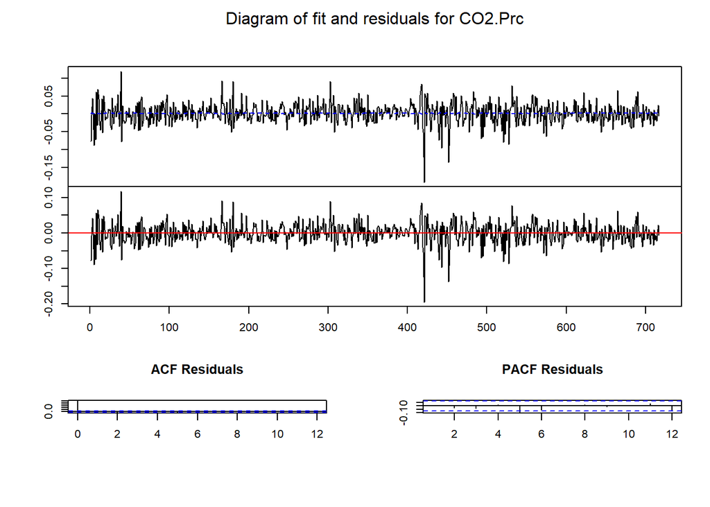

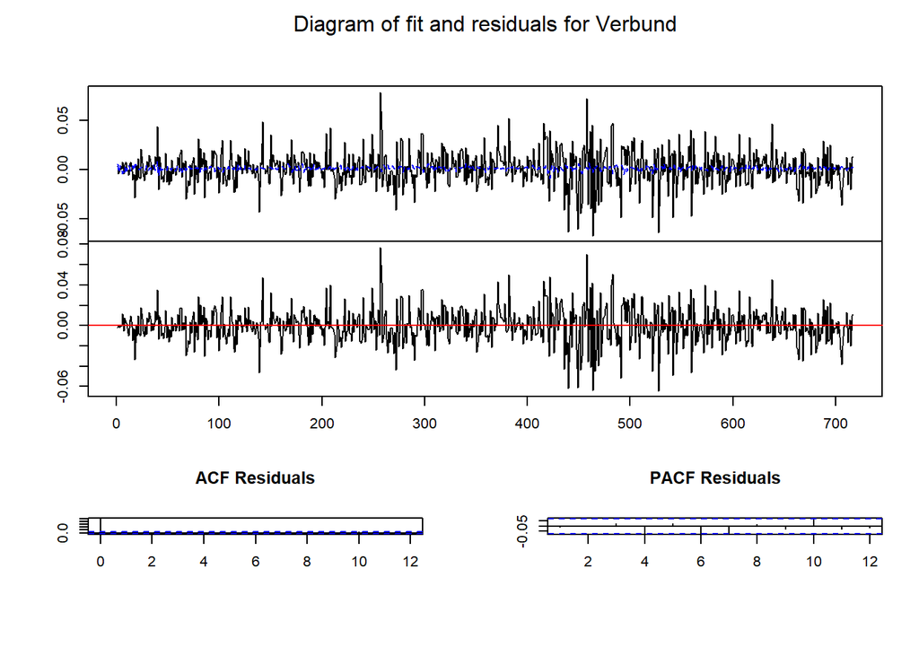

```r
plot(var_verbund1)
```

```r
causality(var_verbund1, cause = "CO2.Prc")
```

```
## $Granger
##
##  Granger causality H0: CO2.Prc do not Granger-cause Verbund
##
## data:  VAR object var_verbund1
## F-Test = 7.6683, df1 = 1, df2 = 1428, p-value = 0.005693
##
##
## $Instant
##
##  H0: No instantaneous causality between: CO2.Prc and Verbund
##
## data:  VAR object var_verbund1
## Chi-squared = 46.103, df = 1, p-value = 1.122e-11
```

Im neu geschätzten vektorautoregressiven Modell scheint der CO2 Return mit Lag 1 immer noch statistisch signifikant unterschiedlich von 0 zu sein.Jedoch hat sich das R-squared auf 0.01232 verbessert. Jetzt kann bereits ca. 1.2% der Variabilität der Zeitreihe mit dem Modell erklärt werden. Ausserdem zeigt der Granger Kausalitäts Test dass, im 95% Konfidenzintervall, Änderungen im CO2 Return immer noch signifikante Änderungen der Verbund AG Returns bewirkt.

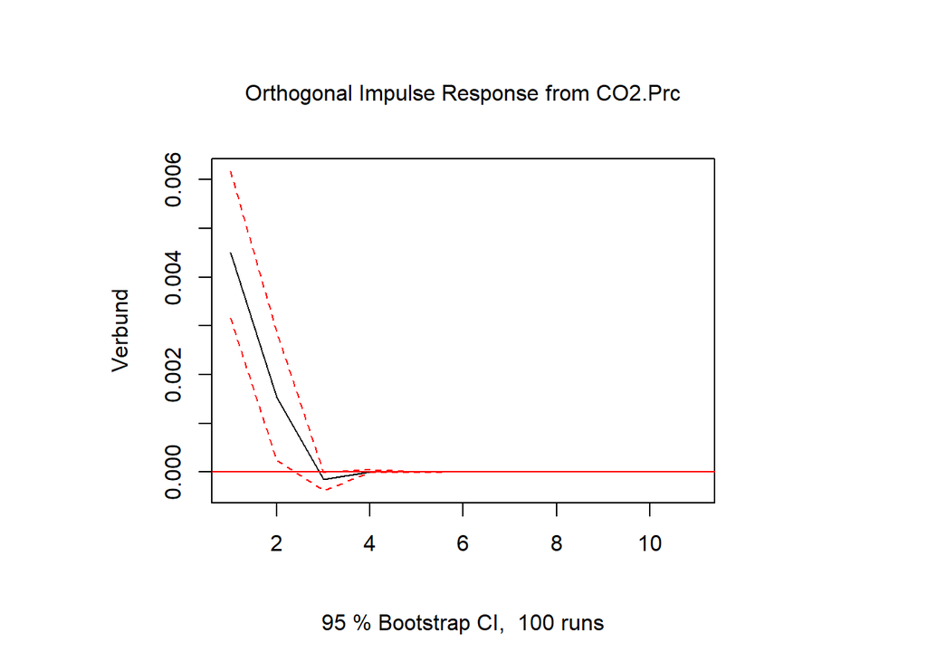

```r
plot(irf(var_verbund1, impulse = "CO2.Prc", response = "Verbund"))
```

Eine Änderung des CO2 Preises bewirkt eine grösse Änderung, über mehrere Perioden, des Returns der Verbund AG als im ersten vektorautoregressiven Modell.